# 3_상관관계분석

## 📏 정규성 검정

본 분석에서는 회귀 및 상관분석에 앞서, 주요 변수들이 **정규분포를 따르는지**를 검정함.  
정규성을 만족하지 않을 경우, **비모수 분석 방법**을 사용해야 함.

### ✅ 검정 방법: Shapiro-Wilk Test

- **Shapiro-Wilk Test**는 정규성을 검정하는 대표적인 통계적 방법으로,  
  `p-value < 0.05`일 경우 **정규성을 만족하지 않는다**고 판단함.
- 분석 대상 변수:
  - `btc_price`, `eth_price`, `doge_price` (암호화폐 가격)
  - `kospi`, `nasdaq` (지수)
  - `kor_rate`, `usa_rate` (금리)
  - `moon_phase`, `weather` (달의 위상, 날씨)

```python
from scipy.stats import shapiro

cols = ['btc_price', 'eth_price', 'doge_price', 'kospi', 'nasdaq', 'kor_rate', 'usa_rate', 'moon_phase', 'partly_cloudy', 'snow', 'clear', 'rain', 'cloudy']

for col in cols:
    stat, p = shapiro(df[col].dropna())
    print(f"{col} → p-value: {p:.4f} → {'✅ 정규분포' if p > 0.05 else '❌ 비정규'}")
```

```
btc_price → p-value: 0.0000 → ❌ 비정규
eth_price → p-value: 0.0000 → ❌ 비정규
doge_price → p-value: 0.0000 → ❌ 비정규
kospi → p-value: 0.0115 → ❌ 비정규
nasdaq → p-value: 0.0000 → ❌ 비정규
kor_rate → p-value: 0.0000 → ❌ 비정규
usa_rate → p-value: 0.0000 → ❌ 비정규
moon_phase → p-value: 0.0000 → ❌ 비정규
partly_cloudy → p-value: 0.0000 → ❌ 비정규
snow → p-value: 0.0000 → ❌ 비정규
clear → p-value: 0.0000 → ❌ 비정규
rain → p-value: 0.0000 → ❌ 비정규
cloudy → p-value: 0.0000 → ❌ 비정규
```

## 📊 상관관계 분석 개요

- 데이터 분포가 정규성을 만족하지 않기 때문에,  
  **비모수 분석**을 적용함
- 이에 따라 **스피어만 상관계수** 를 사용하여  
  암호화폐 가격과 경제 지표 간의 **순위 기반 상관관계**를 분석함

### ✅ 분석 대상 변수

- 종속 변수:  
  `btc_price`, `eth_price`, `doge_price`
- 독립 변수:  
  `kospi`, `nasdaq`, `kor_rate`, `usa_rate`, `moon_phase`, `partly_cloudy`, `snow`, `clear`, `rain`, `cloudy`

### ✅ 분석 기준

- **비모수 상관계수**: rho (ρ)
- **유의수준 (α)**: 0.05  
  → p-value < 0.05인 경우 **통계적으로 유의한 상관관계**로 해석

> 📌 Spearman 상관계수는 데이터의 **값 자체가 아닌 순위(랭크)**를 기반으로 계산되며,  
> 정규성을 만족하지 않는 데이터 간 관계 분석에 적합함.

```python
from scipy.stats import spearmanr

print("📊 스피어만 상관관계 분석 결과:\n")

for target in ['btc_price', 'eth_price', 'doge_price']:
    print(f"▶ {target} 와의 상관계수:")
    for feature in ['kospi', 'nasdaq', 'kor_rate', 'usa_rate', 'moon_phase', 'partly_cloudy', 'snow', 'clear', 'rain', 'cloudy']:
        coef, p = spearmanr(df[target], df[feature])
        print(f"   {feature:10} → ρ = {coef:.4f} (p = {p:.4f}) {'✅ 유의' if p < 0.05 else '⚠️ 유의X'}")
    print()
```

```
📊 스피어만 상관관계 분석 결과:

▶ btc_price 와의 상관계수:
   kospi      → ρ = 0.4156 (p = 0.0000) ✅ 유의
   nasdaq     → ρ = 0.9157 (p = 0.0000) ✅ 유의
   kor_rate   → ρ = -0.5022 (p = 0.0000) ✅ 유의
   usa_rate   → ρ = 0.0843 (p = 0.0199) ✅ 유의
   moon_phase → ρ = -0.0183 (p = 0.6132) ⚠️ 유의X
   partly_cloudy → ρ = -0.0027 (p = 0.9403) ⚠️ 유의X
   snow       → ρ = 0.0384 (p = 0.2895) ⚠️ 유의X
   clear      → ρ = 0.0753 (p = 0.0378) ✅ 유의
   rain       → ρ = -0.0560 (p = 0.1228) ⚠️ 유의X
   cloudy     → ρ = -0.0281 (p = 0.4390) ⚠️ 유의X

▶ eth_price 와의 상관계수:
   kospi      → ρ = 0.5227 (p = 0.0000) ✅ 유의
   nasdaq     → ρ = 0.8604 (p = 0.0000) ✅ 유의
   kor_rate   → ρ = -0.3674 (p = 0.0000) ✅ 유의
   usa_rate   → ρ = 0.1631 (p = 0.0000) ✅ 유의
   moon_phase → ρ = -0.0098 (p = 0.7867) ⚠️ 유의X
   partly_cloudy → ρ = -0.0186 (p = 0.6086) ⚠️ 유의X
   snow       → ρ = 0.0531 (p = 0.1431) ⚠️ 유의X
   clear      → ρ = 0.0604 (p = 0.0958) ⚠️ 유의X
   rain       → ρ = -0.0544 (p = 0.1336) ⚠️ 유의X
   cloudy     → ρ = -0.0105 (p = 0.7732) ⚠️ 유의X

▶ doge_price 와의 상관계수:
   kospi      → ρ = 0.3414 (p = 0.0000) ✅ 유의
   nasdaq     → ρ = 0.8056 (p = 0.0000) ✅ 유의
   kor_rate   → ρ = -0.5160 (p = 0.0000) ✅ 유의
   usa_rate   → ρ = -0.1190 (p = 0.0010) ✅ 유의
   moon_phase → ρ = -0.0064 (p = 0.8590) ⚠️ 유의X
   partly_cloudy → ρ = 0.0285 (p = 0.4318) ⚠️ 유의X
   snow       → ρ = 0.0887 (p = 0.0143) ✅ 유의
   clear      → ρ = 0.1092 (p = 0.0025) ✅ 유의
   rain       → ρ = -0.1542 (p = 0.0000) ✅ 유의
   cloudy     → ρ = 0.0002 (p = 0.9960) ⚠️ 유의X
```

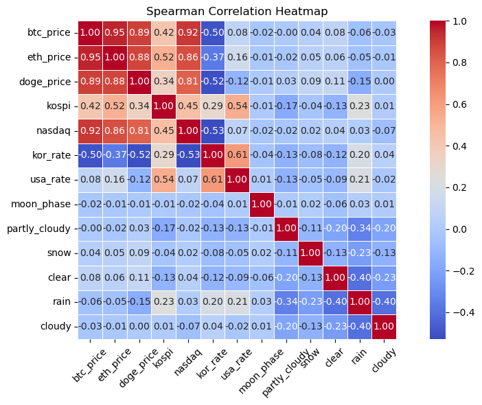

```python
# 히트맵으로 시각화
import seaborn as sns
import matplotlib.pyplot as plt

cols = ['btc_price', 'eth_price', 'doge_price', 'kospi', 'nasdaq', 'kor_rate', 'usa_rate', 'moon_phase', 'partly_cloudy', 'snow', 'clear', 'rain', 'cloudy']
spearman_corr = df[cols].corr(method='spearman')

plt.figure(figsize=(10, 6))
sns.heatmap(spearman_corr, annot=True, cmap='coolwarm', fmt=".2f", linewidths=0.5, square=True)
plt.title("Spearman Correlation Heatmap")
plt.xticks(rotation=45)
plt.yticks(rotation=0)
plt.tight_layout()
plt.show()
```

## 📊 상관관계 분석 결론

## 🔬 가설 1: 경제지표와 암호화폐 가격 간의 관계

- **모든 분석 결과에서 p-value < 0.05**를 만족한 변수들이 다수 존재하였으며, 이에 따라  
  **귀무가설(H₀₁): "암호화폐 가격은 경제 지표와 상관관계가 없다"** 는 기각 → **대립가설(H₁₁): "경제 지표와 상관관계가 있다"를 채택**

### 📌 추가 분석 제안

📝 *보다 정밀한 해석을 위해서는 **달러 마켓(Binance 등) 데이터와의 비교 분석**이 필요함*

- 업비트(원화 마켓) vs 바이낸스(달러 마켓) 간 가격 흐름 비교
- 미국 금리의 영향을 더 직접적으로 반영하는 **USD 기반 가격 데이터 분석** 고려

## 🔬 가설 2: 비정형 요인과 암호화폐 가격 간의 관계

- **달의 위상** 및 **날씨 조건(맑음, 흐림 등)** 과의 관계는 대부분 p-value > 0.05로 나타났으며,  
  이에 따라 **대립가설(H₁₂): "비정형 요인과 상관관계가 있다"** 는 **기각** → **귀무가설(H₀₂): "비정형 요인과 상관관계가 없다"를 채택**

## 🧠 종합 결론

- 암호화폐 가격은 **전통적인 경제 지표(나스닥, 금리, 코스피 등)와 통계적으로 유의한 상관관계**를 가짐
- 반면, **날씨 및 달의 위상 등 비정형 변수는 유의미한 영향력이 없는 것으로 판단됨**

## 📈 선형 관계 분석 (Linear Relationship Analysis)

앞서 수행한 상관관계 분석 결과를 바탕으로 암호화폐 가격에 영향을 미치는 다양한 외부 변수들을  
보다 구체적으로 분석하고자 **다중 선형 회귀분석** 을 수행. 비정형 요인 중 통계적으로 유의한 경향을 보였던 **도지코인(DOGE)과 날씨 변수 간의 관계**도 추가적으로 분석.

### ✅ 분석 목적

- 경제 지표(나스닥, 코스피, 금리 등)가 **암호화폐 가격에 미치는 영향력**을 수치적으로 파악
- 독립 변수들의 조합이 종속 변수(암호화폐 가격)를 **얼마나 잘 설명하는지(R²)** 평가
- 비정형 요인인 날씨가 도지코인 가격에 **실질적인 영향을 미치는지 회귀 분석을 통해 확인**

### ✅ 분석 방식

#### 🔹 경제지표 기반 회귀분석

- **종속 변수**: `btc_price`, `eth_price`, `doge_price` (각각 개별 회귀 모델 구성)
- **독립 변수**: `kospi`, `nasdaq`, `kor_rate`, `usa_rate`
- **도구**: `statsmodels` 라이브러리의 `ols()` 사용

#### 🔹 도지코인-날씨 회귀분석

- **종속 변수**: `doge_price`
- **독립 변수**: `clear`, `cloudy`, `rain`, `snow`, `partly_cloudy` (날씨 상태, one-hot 인코딩)
- **전처리**: 날씨 변수는 0/1 값의 더미 변수로 사용 (추가 정규화 불필요)
- **도구**: `statsmodels` 라이브러리의 `ols()` 사용

```python
# 회귀 분석 실행
import numpy as np
from statsmodels.formula.api import ols

model_btc = ols('btc_price~kospi+nasdaq+kor_rate+usa_rate', df).fit()
model_eth = ols('eth_price~kospi+nasdaq+kor_rate+usa_rate', df).fit()
model_doge = ols('doge_price~kospi+nasdaq+kor_rate+usa_rate', df).fit()
model_weather = ols('doge_price~partly_cloudy+snow+clear+rain+cloudy', df).fit()
```

```python
# 비트코인-경제지표 모델 출력
print(model_btc.summary())
```

```
                            OLS Regression Results
==============================================================================
Dep. Variable:              btc_price   R-squared:                       0.902
Model:                            OLS   Adj. R-squared:                  0.902
Method:                 Least Squares   F-statistic:                     1746.
Date:                Fri, 04 Apr 2025   Prob (F-statistic):               0.00
Time:                        10:52:46   Log-Likelihood:                -195.50
No. Observations:                 762   AIC:                             401.0
Df Residuals:                     757   BIC:                             424.2
Df Model:                           4
Covariance Type:            nonrobust
==============================================================================
                 coef    std err          t      P>|t|      [0.025      0.975]
------------------------------------------------------------------------------
Intercept  -3.344e-16      0.011  -2.94e-14      1.000      -0.022       0.022
kospi          0.0505      0.019      2.641      0.008       0.013       0.088
nasdaq         0.7593      0.024     31.592      0.000       0.712       0.807
kor_rate      -0.2501      0.027     -9.221      0.000      -0.303      -0.197
usa_rate      -0.0494      0.019     -2.608      0.009      -0.087      -0.012
==============================================================================
Omnibus:                       13.138   Durbin-Watson:                   0.041
Prob(Omnibus):                  0.001   Jarque-Bera (JB):               13.616
Skew:                           0.324   Prob(JB):                      0.00111
Kurtosis:                       2.908   Cond. No.                         4.81
==============================================================================

Notes:
[1] Standard Errors assume that the covariance matrix of the errors is correctly specified.
```

## ✅ 1. 비트코인 가격 회귀분석 결과

| 변수 | 계수 (coef) | P-value | 해석 |
| --- | --- | --- | --- |
| nasdaq | 0.7593 | 0.000 | 가장 강한 양의 영향, 매우 유의함 ✅ |
| kor_rate | -0.2501 | 0.000 | 음의 영향, 금리 오르면 가격 하락 ✅ |
| kospi | 0.0505 | 0.008 | 양의 영향, 유의함 ✅ |
| usa_rate | -0.0494 | 0.009 | 약한 음의 영향, 유의함 ✅ |

📌 **R² = 0.902 → 설명력 매우 높음**

> 암호화폐 중에서도 비트코인은 전반적으로 경제지표에 가장 잘 반응하며 설명력이 뛰어남.

```python
# 이더리움-경제지표 모델 출력
print(model_eth.summary())
```

```
                            OLS Regression Results
==============================================================================
Dep. Variable:              eth_price   R-squared:                       0.741
Model:                            OLS   Adj. R-squared:                  0.740
Method:                 Least Squares   F-statistic:                     542.7
Date:                Fri, 04 Apr 2025   Prob (F-statistic):          1.27e-220
Time:                        10:52:46   Log-Likelihood:                -565.88
No. Observations:                 762   AIC:                             1142.
Df Residuals:                     757   BIC:                             1165.
Df Model:                           4
Covariance Type:            nonrobust
==============================================================================
                 coef    std err          t      P>|t|      [0.025      0.975]
------------------------------------------------------------------------------
Intercept   3.591e-16      0.018   1.94e-14      1.000      -0.036       0.036
kospi          0.3135      0.031     10.092      0.000       0.252       0.374
nasdaq         0.5563      0.039     14.236      0.000       0.480       0.633
kor_rate      -0.2491      0.044     -5.649      0.000      -0.336      -0.163
usa_rate       0.0471      0.031      1.528      0.127      -0.013       0.108
==============================================================================
Omnibus:                       18.988   Durbin-Watson:                   0.042
Prob(Omnibus):                  0.000   Jarque-Bera (JB):               19.916
Skew:                           0.396   Prob(JB):                     4.73e-05
Kurtosis:                       3.033   Cond. No.                         4.81
==============================================================================

Notes:
[1] Standard Errors assume that the covariance matrix of the errors is correctly specified.
```

## ✅ 2. 이더리움 가격 회귀분석 결과

| 변수 | 계수 (coef) | P-value | 해석 |
| --- | --- | --- | --- |
| nasdaq | 0.5563 | 0.000 | 가장 큰 영향력, 유의함 ✅ |
| kor_rate | -0.2491 | 0.000 | 음의 영향, 유의함 ✅ |
| kospi | 0.3135 | 0.000 | 강한 양의 영향, 유의함 ✅ |
| usa_rate | 0.0471 | 0.127 | ❌ 통계적으로 유의하지 않음 (p > 0.05) |

📌 **R² = 0.741 → 중간 이상 설명력**

> 이더리움도 경제 지표에 영향받지만 비트코인보다는 조금 덜 민감함.

```python
# 도지코인-경제지표 모델 출력
print(model_doge.summary())
```

```
                            OLS Regression Results
==============================================================================
Dep. Variable:             doge_price   R-squared:                       0.821
Model:                            OLS   Adj. R-squared:                  0.820
Method:                 Least Squares   F-statistic:                     868.2
Date:                Fri, 04 Apr 2025   Prob (F-statistic):          4.65e-281
Time:                        10:52:46   Log-Likelihood:                -425.70
No. Observations:                 762   AIC:                             861.4
Df Residuals:                     757   BIC:                             884.6
Df Model:                           4
Covariance Type:            nonrobust
==============================================================================
                 coef    std err          t      P>|t|      [0.025      0.975]
------------------------------------------------------------------------------
Intercept  -2.776e-16      0.015  -1.81e-14      1.000      -0.030       0.030
kospi          0.0257      0.026      0.994      0.321      -0.025       0.076
nasdaq         0.3915      0.033     12.040      0.000       0.328       0.455
kor_rate      -0.5667      0.037    -15.446      0.000      -0.639      -0.495
usa_rate      -0.1099      0.026     -4.287      0.000      -0.160      -0.060
==============================================================================
Omnibus:                       55.073   Durbin-Watson:                   0.057
Prob(Omnibus):                  0.000   Jarque-Bera (JB):              210.429
Skew:                           0.200   Prob(JB):                     2.02e-46
Kurtosis:                       5.543   Cond. No.                         4.81
==============================================================================

Notes:
[1] Standard Errors assume that the covariance matrix of the errors is correctly specified.
```

## ✅ 3. 도지코인 가격 회귀분석 결과

| 변수 | 계수 (coef) | P-value | 해석 |
| --- | --- | --- | --- |
| nasdaq | 0.3915 | 0.000 | 유의한 양의 영향 ✅ |
| kor_rate | -0.5667 | 0.000 | 가장 강한 음의 영향, 매우 유의 ✅ |
| usa_rate | -0.1099 | 0.000 | 유의한 음의 영향 ✅ |
| kospi | 0.0257 | 0.321 | ❌ 유의하지 않음 (p > 0.05) |

📌 **R² = 0.821 → 설명력 좋음**

> 도지코인은 한국 금리에 특히 민감하며 미국 금리에도 영향 받음.

## 🔍 종합 비교

| 항목 | BTC | ETH | DOGE |
| --- | --- | --- | --- |
| 📈 가장 큰 영향 | 나스닥 | 나스닥 | 한국 금리 |
| 📉 가장 큰 음의 영향 | 한국 금리 | 한국 금리 | 한국 금리 |
| 💡 미국 금리 유의? | ✅ 있음 | ❌ 없음 | ✅ 있음 |
| 🧠 설명력 (R²) | 0.902 | 0.741 | 0.821 |

```python
# 도지코인-날씨 모델 출력
print(model_weather.summary())
```

```
                            OLS Regression Results
==============================================================================
Dep. Variable:             doge_price   R-squared:                       0.049
Model:                            OLS   Adj. R-squared:                  0.044
Method:                 Least Squares   F-statistic:                     9.796
Date:                Fri, 04 Apr 2025   Prob (F-statistic):           9.94e-08
Time:                        10:52:46   Log-Likelihood:                -1062.0
No. Observations:                 762   AIC:                             2134.
Df Residuals:                     757   BIC:                             2157.
Df Model:                           4
Covariance Type:            nonrobust
=================================================================================
                    coef    std err          t      P>|t|      [0.025      0.975]
---------------------------------------------------------------------------------
Intercept         0.0864      0.034      2.506      0.012       0.019       0.154
partly_cloudy     0.1386      0.084      1.657      0.098      -0.026       0.303
snow              0.2285      0.114      2.004      0.045       0.005       0.452
clear             0.1664      0.075      2.226      0.026       0.020       0.313
rain             -0.3212      0.057     -5.636      0.000      -0.433      -0.209
cloudy           -0.1260      0.075     -1.676      0.094      -0.274       0.022
==============================================================================
Omnibus:                      254.558   Durbin-Watson:                   0.063
Prob(Omnibus):                  0.000   Jarque-Bera (JB):              609.082
Skew:                           1.809   Prob(JB):                    5.49e-133
Kurtosis:                       5.469   Cond. No.                     1.23e+16
==============================================================================

Notes:
[1] Standard Errors assume that the covariance matrix of the errors is correctly specified.
[2] The smallest eigenvalue is 6.4e-30. This might indicate that there are
strong multicollinearity problems or that the design matrix is singular.
```

## ✅ 4. 도지코인과 날씨 회귀분석 결과

| 변수 | 계수 (coef) | P-value | 해석 |
| --- | --- | --- | --- |
| **partly_cloudy** | 0.1386 | 0.098 | ⚠️ 유의수준 0.1 근처, **애매한 영향** |
| **snow** | 0.2285 | 0.045 | ✅ **양의 영향**, 눈 오는 날에 도지코인 가격 상승 가능성 |
| **clear** | 0.1664 | 0.026 | ✅ **양의 영향**, 맑은 날 도지코인 가격 상승 가능성 |
| **rain** | -0.3212 | 0.000 | ✅ **음의 영향**, 비 오는 날 도지코인 가격 하락 경향 |
| **cloudy** | -0.1260 | 0.094 | ⚠️ 유의수준 0.1 부근, 뚜렷한 해석 어려움 |

📌 **R² = 0.049 → 설명력 나쁨**

### 📌 해석 요약

- 날씨 조건이 도지코인 가격에 **일정 부분 영향을 미칠 수 있음**을 시사
- **맑은 날과 눈 오는 날**에는 도지코인 가격이 다소 상승하는 경향
- 반면, **비 오는 날에는 유의미한 하락 경향** 존재
- 다만 전체 설명력(R²)이 낮기 때문에, **날씨만으로 도지코인 가격을 설명하기는 어려움**

## 🧪 다중공선성 확인 (Multicollinearity Check)

다중 선형 회귀분석을 수행할 때,  
독립 변수들 간에 **서로 높은 상관관계가 존재할 경우**  
→ 회귀 계수 해석이 왜곡되거나 통계적으로 유의하지 않게 나타날 수 있음

### ✅ 해석 기준

| VIF 값 | 해석 |
| --- | --- |
| **1 ~ 5** | 다중공선성 문제 없음 (안정적) ✅ |
| **5 이상** | 공선성 존재 가능성 있음 (주의 필요) ⚠️ |
| **10 이상** | 심각한 공선성 (모델 재설계 권장) ❌ |

```python
# 다중공선성 확인
from statsmodels.stats.outliers_influence import variance_inflation_factor
import pandas as pd

X = df[['kospi', 'nasdaq', 'kor_rate', 'usa_rate']]
vif = pd.DataFrame()
vif['Variable'] = X.columns
vif['VIF'] = [variance_inflation_factor(X.values, i) for i in range(X.shape[1])]

print(vif)
```

```
   Variable       VIF
0     kospi  2.824738
1    nasdaq  4.471391
2  kor_rate  5.693328
3  usa_rate  2.780488
```

## ✅ 다중공선성 검사 결과 (VIF)

| 변수 | VIF 값 | 해석 |
| --- | --- | --- |
| `kospi` | 2.82 | ✅ 다중공선성 문제 없음 |
| `nasdaq` | 4.47 | ✅ 다중공선성 문제 없음 |
| `kor_rate` | 5.69 | ⚠️ 약한 다중공선성 가능성 있음 (주의 요망) |
| `usa_rate` | 2.78 | ✅ 다중공선성 문제 없음 |

### 📌 결론

- 대부분의 변수는 **VIF < 5**로, 다중공선성 문제는 크지 않음
- `kor_rate`의 경우 **VIF ≈ 5.69**로 **약간의 공선성 가능성**이 있으나  
  분석 해석에 큰 영향을 주지는 않는 수준

> 따라서, 현재 회귀모델은 **다중공선성 측면에서 비교적 안정적**이라고 판단 가능

### 📈 경제 지표 분석 결과

- **나스닥 지수**는 모든 암호화폐(BTC, ETH, DOGE)에 대해 가장 강한 양(+)의 영향력을 보였으며,  
  특히 **비트코인 가격과의 관계가 가장 뚜렷**했다.
- **금리(특히 한국 기준금리)**는 이더리움, 도지코인에 음(-)의 영향으로 나타나,  
  **금리 인상 시 가격이 하락하는 경향**을 보임.
- **코스피 지수**는 상관분석에서는 유의미했지만, 회귀분석에서는 도지코인에 유의하지 않은 변수로 나타나  
  **다른 지표에 비해 영향력이 약함**을 시사함.

### 🌦️ 날씨와 도지코인 가격

- 날씨 변수들은 낮은 설명력을 보였으나,  
  `맑음(clear)`, `눈(snow)`은 도지코인 가격 상승과 유의한 양의 관계를,  
  `비(rain)`는 유의한 음의 관계를 보임.
- 하지만 결정계수 **R² = 0.049**로 모델의 설명력이 낮아, **기후 변수 단독으로 도지코인 가격을 설명하기엔 한계**가 있음.

### 🧠 다중공선성 검사

- 경제 지표 변수들에 대해 VIF를 확인한 결과, **모두 10 미만**으로 **다중공선성 문제는 없는 수준**임을 확인함.
- 따라서 회귀 계수 해석에 큰 무리는 없음.

### 📌 정태적 분석 종합 정리

- **암호화폐 가격은 거시경제 지표의 영향을 크게 받으며**,  
  특히 글로벌 금융시장의 흐름을 반영하는 **나스닥 지수와의 관계가 가장 강함**.
- 날씨 등의 외부 요인을 통해 **도지코인과 같은 밈코인의 변동성을 보완적으로 설명할 수 있는 가능성**도 확인됨.

## ⏱️ 시계열 특성을 고려한 상관 분석

앞선 상관관계 분석은 시계열 데이터를 단순 수치형 변수로 처리하여, 시간 흐름에 따른 영향은 고려하지 않은 정태적 분석이었다.  
그러나 암호화폐 가격과 외부 요인은 모두 **시계열적 특성**을 가지므로 **시간의 흐름에 따른 관계성**을 분석하는 것이 더 현실적이고 타당하다.

### ✅ 1. 시차 상관관계 분석 (Cross-Correlation Function)

- 암호화폐 가격과 외부 요인 간에 **며칠 후에 영향을 주고받는가?** 를 파악하기 위해 CCF 분석을 수행하였다.
- 각 변수 쌍에 대해 lag 0~29일 범위의 시차를 적용해 상관계수를 계산하였고 가장 강한 상관을 보인 lag 값을 기록하였다.

[figure not shown]

```python
import numpy as np
import pandas as pd
from statsmodels.tsa.stattools import ccf
import matplotlib.pyplot as plt
import seaborn as sns

df_norm = pd.read_csv['암호화폐_금리_지수_월령_날씨_병합데이터_정규화.csv']

# 설정
crypto_cols = ['btc_price', 'eth_price', 'doge_price']
external_cols = ['kospi', 'nasdaq', 'kor_rate', 'usa_rate', 'moon_phase',
                 'partly_cloudy', 'snow', 'clear', 'rain', 'cloudy']
max_lag = 30
summary_data = []

# CCF 계산
for coin in crypto_cols:
    for external in external_cols:
        series1 = df_norm[coin]
        series2 = df_norm[external]
        min_len = min(len(series1), len(series2))
        series1 = series1[:min_len]
        series2 = series2[:min_len]

        # CCF 계산 (lag 0 ~ 29)
        corr_values = ccf(series1, series2)[:max_lag]
        max_corr = np.max(np.abs(corr_values))
        best_lag = np.argmax(np.abs(corr_values))

        summary_data.append({
            'coin': coin,
            'external_variable': external,
            'max_abs_correlation': max_corr,
            'best_lag': best_lag,
            'annot': f"{max_corr:.2f}\n(lag={best_lag})"
        })

# DataFrame 변환
ccf_summary_df = pd.DataFrame(summary_data)

# 피벗 테이블 생성
heatmap_values = ccf_summary_df.pivot(index='coin', columns='external_variable', values='max_abs_correlation')
heatmap_annots = ccf_summary_df.pivot(index='coin', columns='external_variable', values='annot')

# 시각화
plt.figure(figsize=(12, 6))
sns.heatmap(heatmap_values, annot=heatmap_annots, fmt='', cmap='coolwarm', cbar=True)
plt.title("Coin vs External Variable - Max Abs Correlation + Lag")
plt.ylabel("Cryptocurrency")
plt.xlabel("External Variable")
plt.tight_layout()
plt.show()
```

### 🔍 주요 해석 요약

#### 📌 변수별 상세 해석

##### 🟠 `btc_price` (비트코인)

- **NASDAQ**: `0.93 (lag=0)` → 매우 강한 동시 상관관계. 미국 증시 움직임이 즉각 반영됨
- **kor_rate**: `0.70 (lag=0)` → 한국 기준금리와의 강한 즉시 반응
- **기타 요인**(moon_phase, 날씨 등): 상관계수 0.2 이하, 시차 있음 → 영향 미미

##### 🔷 `eth_price` (이더리움)

- **NASDAQ**: `0.84 (lag=0)` → 기술주 중심 시장과 강한 연동
- **kospi**: `0.52 (lag=0)` → 국내 주가 지수와도 중간 수준 동시 반응
- **kor_rate**: `0.44 (lag=0)` → 금리 영향 있음
- 날씨 관련 변수는 모두 0.2 이하의 상관 → 영향 없음

### 🧾 요약

- 주요 암호화폐들은 NASDAQ, 금리 등 금융 지표와 **동시에 강하게 반응**
- 날씨, 달의 위상과 같은 비정형 변수는 **시차가 존재해도 상관이 매우 낮아 영향력 없음**
- 다만, CCF는 단기 반응만을 측정하므로, **장기적인 관계는 별도로 공적분 분석을 통해 검토함**

### ✅ 2. 공적분 분석 (Cointegration Test)

- 비정상 시계열인 암호화폐 가격과 외부 요인 간에 **장기적인 균형 관계**가 존재하는지를 검증
- Engle-Granger 공적분 검정을 통해 3개 코인 × 외부 요인 전체 조합에 대해 p-value를 산출

```python
import pandas as pd
import numpy as np
from statsmodels.tsa.stattools import coint

df = pd.read_csv('암호화폐_금리_지수_월령_날씨_병합데이터.csv')

crypto_cols = ['btc_price', 'eth_price', 'doge_price']
external_cols = ['kospi', 'nasdaq', 'kor_rate', 'usa_rate', 'moon_phase',
                 'partly_cloudy', 'snow', 'clear', 'rain', 'cloudy']
cointegration_results = []

for coin in crypto_cols:
    for external in external_cols:
        y1 = df[coin]
        y2 = df[external]
        min_len = min(len(y1), len(y2))
        y1 = y1[:min_len]
        y2 = y2[:min_len]

        coint_stat, p_value, _ = coint(y1, y2)

        cointegration_results.append({
            'coin': coin,
            'external_variable': external,
            'coint_statistic': coint_stat,
            'p_value': p_value
        })

coint_df = pd.DataFrame(cointegration_results)
coint_df_sorted = coint_df.sort_values(by='p_value')

# 5. 출력
print(coint_df_sorted)
```

```
          coin external_variable  coint_statistic   p_value
22  doge_price          kor_rate        -3.501476  0.032265
2    btc_price          kor_rate        -3.102715  0.087759
12   eth_price          kor_rate        -2.512210  0.273711
11   eth_price            nasdaq        -2.191571  0.428714
1    btc_price            nasdaq        -2.079673  0.486996
21  doge_price            nasdaq        -2.060667  0.496934
23  doge_price          usa_rate        -1.834915  0.612613
16   eth_price              snow        -1.569859  0.733442
10   eth_price             kospi        -1.557166  0.738625
18   eth_price              rain        -1.523708  0.751989
17   eth_price             clear        -1.500560  0.760977
14   eth_price        moon_phase        -1.334608  0.819048
19   eth_price            cloudy        -1.328706  0.820906
15   eth_price     partly_cloudy        -1.320458  0.823477
```

[output cut: 16 more lines]

### 📊 분석 결과

- 대부분의 변수 쌍은 **p-value > 0.05**로 공적분 관계가 없는 것으로 나타남
- 단, 다음 조합에서 **p-value < 0.05**로 유의미한 공적분 관계가 존재

| 코인 | 외부 요인 | 통계량 | p-value | 해석 |
| --- | --- | --- | --- | --- |
| `doge_price` | `kor_rate` | -3.501476 | 0.032265 | 도지코인과 한국 기준금리는 장기적으로 균형관계를 유지 |

### 🧠 해석

- `doge_price`와 `kor_rate`의 공적분 관계는,  
  → 도지코인 가격과 한국 기준금리 간의 **장기적 연동성**이 존재할 수 있음을 시사
- 즉, 단기적으로 이탈이 있더라도 시간이 지나면서 **다시 수렴**하는 성향이 있음
- 반면, 대부분의 외부 요인(금리, 주가지수, 날씨 등)과 코인 가격 간에는  
  → **장기적 균형관계 없음** → 가격이 따로 움직이는 독립적 경향

### 📌 요약

- 공적분 분석 결과, 단 하나의 조합(`doge_price - kor_rate`)을 제외하고는  
  암호화폐 가격과 외부 요인 간에 **장기적인 통계적 연관성은 확인되지 않음**
- 이는 암호화폐가 여전히 **전통적 외부 요인과 구조적으로 연결되어 있지 않다**는 점을 시사함

## ✅ 최종 결론

[output not shown]